# Analyses of GSE138988; GSE224858; GSE224752

## Filtration

### *Before Filtration*

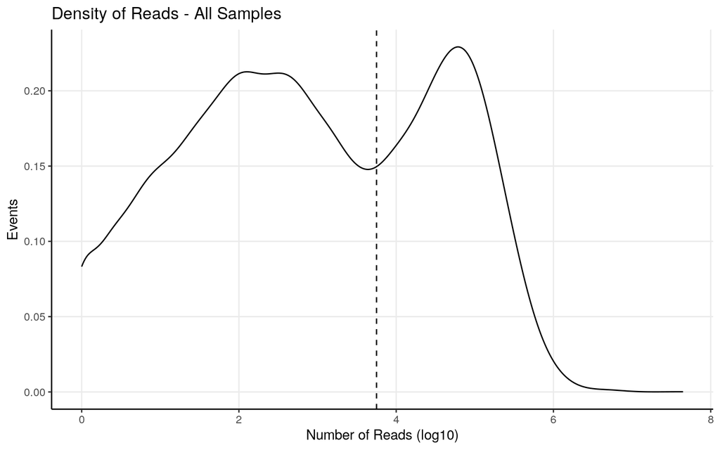

```r
alternew <- log10(rowSums(read.counts))
alternew <- as.data.frame(alternew)

ggplot(alternew, aes(x=alternew)) + geom_density() + theme_bw() + geom_vline(xintercept = 3.75, linetype = "dashed") + ylab("Events") + xlab("Number of Reads (log10)") +
  theme(axis.line = element_line(colour = "black"),
        panel.grid.minor = element_blank(),
        panel.border = element_blank(),
        panel.background = element_blank()) + ggtitle("Density of Reads - All Samples")
```

### *After Filtration*

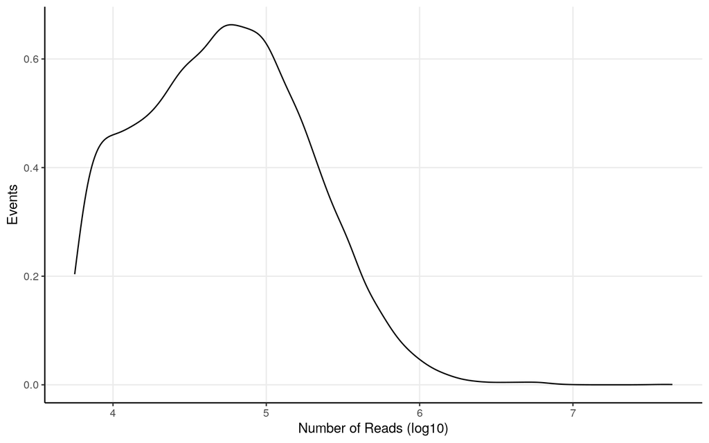

```r
MitoGenes <- fread("~/MitoGenes.txt", header = FALSE)[[1]]
filterednew <- subset(read.counts, alternew>3.75)


#after cutting, its a good idea to visualize again
falternew <- log10(rowSums(filterednew))
falternew <- as.data.frame(falternew)
ggplot(falternew, aes(x=falternew)) + geom_density() + theme_bw() + ylab("Events") + xlab("Number of Reads (log10)") +
  theme(axis.line = element_line(colour = "black"),
        panel.grid.minor = element_blank(),
        panel.border = element_blank(),
        panel.background = element_blank())
```

```r
#lets save the genes which we maintain
impgenes <- c(row.names(falternew), MitoGenes)


#Now we need to select only the rows which have those genes.
finaltable <- read.counts[row.names(read.counts)%in%impgenes,]
```

## Matrices

Good! Now we can proceed by designing our matrices.

```
## Coefficients not estimable: CellU2-OS
```

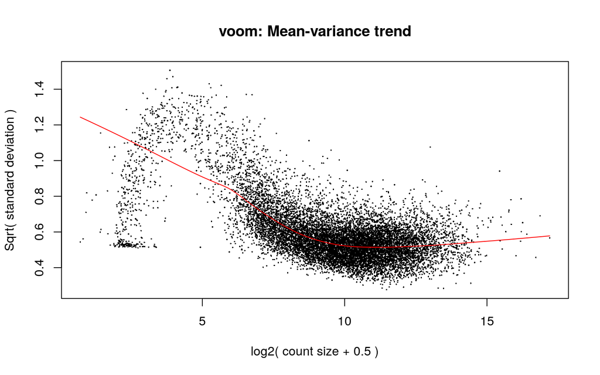

```r
sampletype <- c(rep("PB",3), rep("WC",3), rep("DC",3),rep("WC",3),rep("FC",12), rep("WC",15))
g3state <- c(rep("WT",3), rep("WT",3), rep("GFP",3),rep("GFP",3), rep("mCHerry",27))
forstress <- c(rep("AS",12),rep("UV",3), rep("OS",3),rep("HS",3), rep("AS",3),rep("UV",3), rep("OS",3),rep("HS",3), rep("AS",3), rep("UN",3))
Celltype <- c(rep("U2-OS",12), rep("HeLa",27))

metadata <- data.frame(Sample=sampletype, G3=g3state, Stress=forstress, Cell=Celltype)

#To be able to use Voom, we must first convert our read count table into a special DGE object.
D0 <- DGEList(finaltable)

#for the others, we need to select only relevant columns.

#Then we calculate the normalization factors.
#Bear in mind this step calculates the normalization factors, but does not normalize itself.
D0 <- calcNormFactors(D0)


#Now we do our matrix itself
mm <- model.matrix(~0+Sample+G3+Stress+Cell, metadata)

#and now we normalize. This step also turns our counts into log2-counts per million.
y <- voom(D0, mm, plot = T)
```

## Normalisation

For normalisation I convert the read counts into log2CPMs. Its a good way to visualize how the reads are.

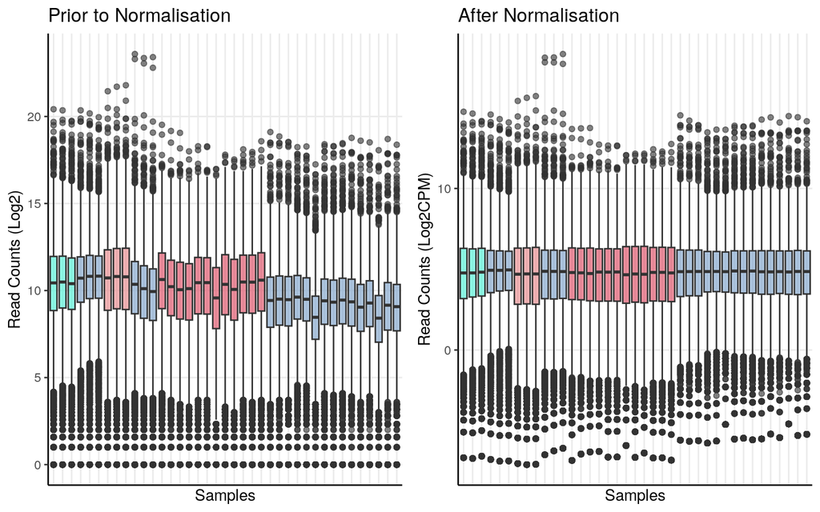

```r
dfforboxy <- finaltable

orderforplots <- sampletype
colouring <- data.frame(Sample=colnames(dfforboxy), Types=orderforplots)
dfforboxy <- reshape2::melt(dfforboxy)
colnames(dfforboxy) <- c("Sample", "Expression")
dfforboxy <- merge(dfforboxy, colouring, by="Sample")
prenorm <- ggplot(dfforboxy, aes(x=Sample, y=(log2(Expression+1)), fill=Types)) + geom_boxplot(alpha=0.6) + theme_bw() + ylab("Read Counts (Log2)") + xlab("Samples") + scale_fill_manual(name = "Sample Type", values = c("#43F3D5", "#769fca", "#e88184", "#de425b"), labels=unique(sampletype), breaks =unique(sampletype)) +
  theme(axis.line = element_line(colour = "black"),
        panel.grid.minor = element_blank(),
        panel.border = element_blank(),
        panel.background = element_blank(),
        axis.text.x=element_blank(),
        axis.ticks.x=element_blank(),
        legend.position = "None") + ggtitle("Prior to Normalisation")

dfforboxy <- y$E
dfforboxy <- reshape2::melt(dfforboxy)
dfforboxy <- dfforboxy[,-1]
colnames(dfforboxy) <- c("Sample", "Expression")
dfforboxy <- merge(dfforboxy, colouring, by="Sample")
postnorm <- ggplot(dfforboxy, aes(x=Sample, y=Expression, fill=Types)) + geom_boxplot(alpha=0.6) + theme_bw() + ylab("Read Counts (Log2CPM)") + xlab("Samples") + scale_fill_manual(name = "Sample Type", values = c("#43F3D5", "#769fca", "#e88184", "#de425b"), labels=unique(sampletype), breaks =unique(sampletype)) +
  theme(axis.line = element_line(colour = "black"),
        panel.grid.minor = element_blank(),
        panel.border = element_blank(),
        panel.background = element_blank(),
        axis.text.x=element_blank(),
        axis.ticks.x=element_blank(),
        legend.position = "None") + ggtitle("After Normalisation")

ggarrange(prenorm, postnorm, nrow=1)
```

## PCA

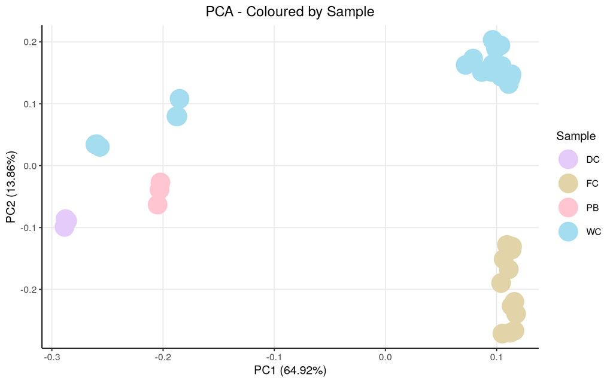

```r
# Define color palette
custom_palette <- qualitative_hcl(5, palette = "Pastel")
custom_palette <- sample(custom_palette, 5)

#This prepares my data for the PCA
dfforpca <- y$E
dfforpca <- t(dfforpca)
dfforpca <- as.data.frame(dfforpca) # needs to be a data.frame
dfforpca <- apply(dfforpca, 2, as.numeric) # Ensure numeric
dfforpca <- as.data.frame(dfforpca) # still needs to be a data.frame

dfforpca$Sample <- sampletype
dfforpca$G3 <- g3state
dfforpca$Stress <- forstress
dfforpca$Cell <- Celltype

# PCA computation itself. I do one PCA for each variable I want to see.
pca_res <- prcomp(dfforpca[, 1:(ncol(dfforpca)-4)], scale = FALSE)

p_Sample <- autoplot(pca_res, data = dfforpca, x = 1, y = 2, colour = "Sample", size = 8) +
  theme_bw() +
  scale_colour_manual(name = "Sample", values = custom_palette) +
  ggtitle("PCA - Coloured by Sample") +
  theme(plot.title = element_text(hjust = 0.5),
        axis.line = element_line(colour = "black"),
        panel.grid.minor = element_blank(),
        panel.border = element_blank(),
        panel.background = element_blank())

p_g3 <- autoplot(pca_res, data = dfforpca, x = 1, y = 2, colour = "G3", size = 8) +
  theme_bw() +
  scale_colour_manual(name = "G3", values = custom_palette) +
  ggtitle("PCA - Coloured by G3") +
  theme(plot.title = element_text(hjust = 0.5),
        axis.line = element_line(colour = "black"),
        panel.grid.minor = element_blank(),
        panel.border = element_blank(),
        panel.background = element_blank())

p_Stress <- autoplot(pca_res, data = dfforpca, x = 1, y = 2, colour = "Stress", size = 8) +
  theme_bw() +
  scale_colour_manual(name = "Stress", values = custom_palette) +
  ggtitle("PCA - Coloured by Stress") +
  theme(plot.title = element_text(hjust = 0.5),
        axis.line = element_line(colour = "black"),
        panel.grid.minor = element_blank(),
        panel.border = element_blank(),
        panel.background = element_blank())

p_Cell <- autoplot(pca_res, data = dfforpca, x = 1, y = 2, colour = "Cell", size = 8) +
  theme_bw() +
  scale_colour_manual(name = "Cell", values = custom_palette) +
  ggtitle("PCA - Coloured by Cell") +
  theme(plot.title = element_text(hjust = 0.5),
        axis.line = element_line(colour = "black"),
        panel.grid.minor = element_blank(),
        panel.border = element_blank(),
        panel.background = element_blank())

p_Sample
```

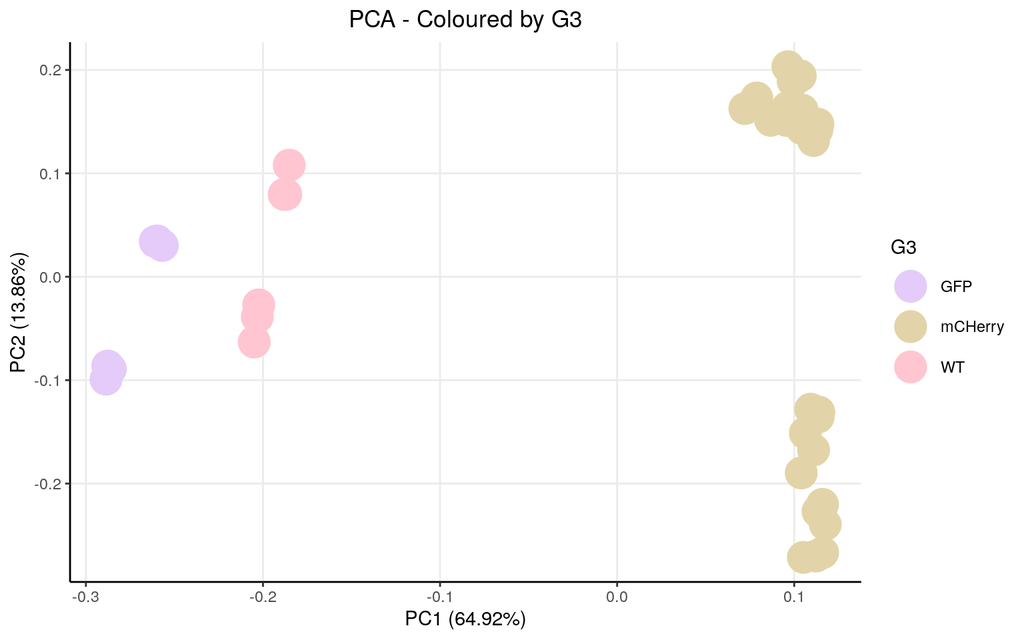

```r
p_g3
```

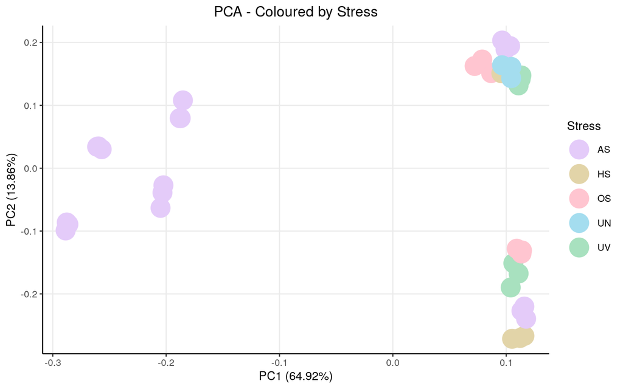

```r
p_Stress
```

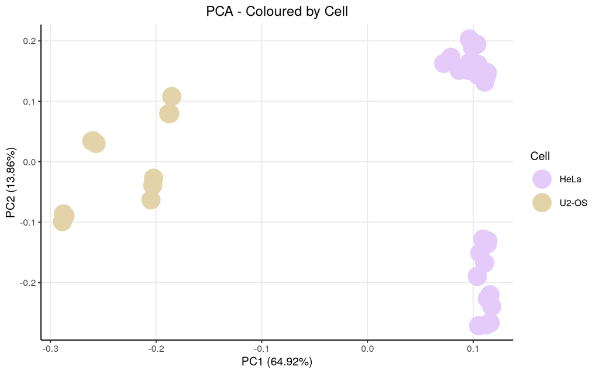

```r
p_Cell
```

```r
#in case you want to see most important genes for PCA yourself
contribs1 <- pca_res$rotation[,1]
contribs2 <- pca_res$rotation[,2]

#These are the biggest contributors to the PCA1 (right side)
(pos1genes <- sort(contribs1, decreasing=T)[1:10])
```

```
##        GDA      C4BPA       CD24       H3C8     CDKN2A      NPTX1     ZNF831
## 0.04348362 0.04088260 0.03988418 0.03956985 0.03922992 0.03857975 0.03821428
##     MARCKS      ECEL1       IRS2
## 0.03804442 0.03676148 0.03664639
```

```r
#These are the biggest contributors to the PCA1 (left side)
(neg1genes <- sort(contribs1, decreasing=F)[1:10])
```

```
##       CCND2       ALCAM      ADAM19       BCAT1      COL6A3        PEG3
## -0.04255565 -0.04214597 -0.04171774 -0.04152210 -0.04124226 -0.03947215
##     MT-RNR2    FAM171A1     ZNF518B      DPYSL3
## -0.03942258 -0.03937923 -0.03910161 -0.03902542
```

```r
#These are the biggest contributors to the PCA2 (up side)
(pos2genes <- sort(contribs2, decreasing=T)[1:10])
```

```
##      RPPH1      RN7SK        7SK   SCARNA13    SCARNA2  RN7SKP203      MT-TW
## 0.05177872 0.04819631 0.04755740 0.04711178 0.04563469 0.04533400 0.04525779
##   SNORA17B   SNORA73B       RMRP
## 0.04504539 0.04330067 0.04325203
```

```r
#These are the biggest contributors to the PCA2 (down side)
(neg2genes <- sort(contribs2, decreasing=F)[1:10])
```

```
##      ZNF892        AKT3        CDK6       BNIP2      GTF2A1      LRRC58
## -0.01899842 -0.01883276 -0.01866930 -0.01835268 -0.01828299 -0.01810289
##     B4GALT6        RO60      ZBTB41       ARL5B
## -0.01804865 -0.01804162 -0.01790411 -0.01785886
```

As one can observe from the PCAs, our PC1 is mostly explained by G3 status, while our PC2 is explained by sample type. For this particular experiment, in my opinion, G3 status isn’t relevant, so I will batch correct for that.